# Quarto Homework

STAT 184

Author

Gianna DeLorenzo

Published

November 20, 2024

## Question 1

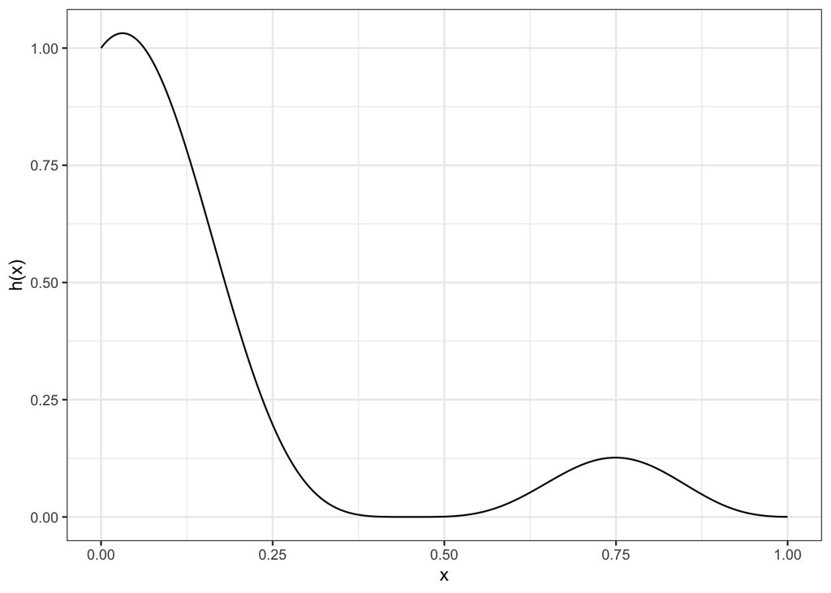

## Question 2

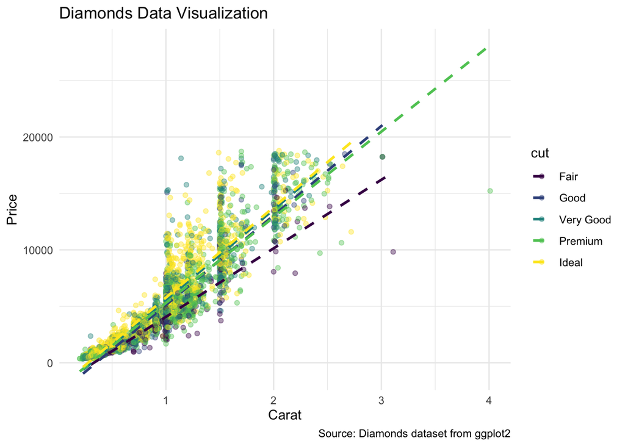

```r
#Load necessary libraries
library(dplyr)
#Import the diamonds dataset
data(diamonds)

#Take a sample of the dataset
diamonds_sample <- sample_n(diamonds, 5000)

#Create the plot
diamonds_aesthetics <- ggplot(diamonds_sample,
                              aes(x = carat,
                                  y = price,
                                  color = cut)) +
  geom_point(alpha = 0.4) + #Reduced alpha and smaller data points
  geom_smooth(se = FALSE, method = "lm", linetype = "dashed") +
  labs(x = "Carat",
       y = "Price",
       title = "Diamonds Data Visualization",
       caption = "Source: Diamonds dataset from ggplot2") +
  theme_minimal() #Polished look of visualization

#Display the visualization
diamonds_aesthetics
```

## Question 3

**Data includes 6 states bordering the U.S. including:**

- Baja California
- Sonora
- Chihuahua
- Coahuila
- Nuevo León
- Tamaulipas

```r
#Load necessary libraries
library(dplyr)
library(ggplot2)
library(knitr)

#Import tortilla data csv file
tortilla_prices_data <- read.csv("/Users/giannadelorenzo/Downloads/STAT 184/tortilla_data.csv")
```

**Task A:** Find average price of tortillas across all 6 states together for the year 2007.

```r
#Average price for 2007
avg_price_2007 <- tortilla_prices_data %>%
  filter(year == 2007) %>% #Filters for year 2007
  summarise(
    avg_price = mean(price, na.rm = TRUE) #Gets average of price column and filters missing data
  )
avg_price_2007
```

```
  avg_price
1  7.684157
```

**Task B:** Find the average price of tortillas across all 6 states together for the year 2024.

```r
#Average price for 2024
avg_price_2024 <- tortilla_prices_data %>%
  filter(year == 2024) %>% #Filters for year 2024
  summarise(
    avg_price = mean(price, na.rm = TRUE) #Gets average of price column and filters missing data
  )
avg_price_2024
```

```
  avg_price
1  20.47146
```

**Task C:** Find the percent change in the average price of tortillas across all 6 states together from the year 2007 to 2024.

```r
#Calculate the percent change in the average price from 2007 to 2024
avg_price_percent_change <- ((avg_price_2024$avg_price - avg_price_2007$avg_price) / avg_price_2007$avg_price) * 100
avg_price_percent_change
```

```
[1] 166.4113
```

**Task D:** Make a plot that shows the average price of tortillas (across all 6 states together) each year from the years 2007 to 2024.

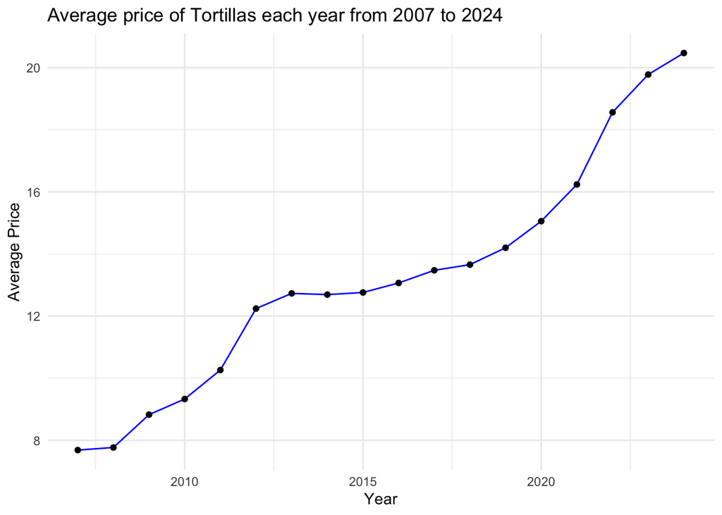

```r
#Average price each year from 2007 to 2024
avg_price_plot <- tortilla_prices_data %>%
  group_by(year) %>%
  summarise(
    avg_price = mean(price, na.rm = TRUE)
  )

#Create the visualization
ggplot(avg_price_plot,
       aes(x = year,
           y = avg_price)) +
  geom_line(color = "blue") +
  geom_point() +
  labs(x = "Year",
       y = "Average Price",
       title = "Average price of Tortillas each year from 2007 to 2024") +
  theme_minimal()
```

**Task E:** For the year 2016, provide summary statistics for each of the six states’ price of tortillas. Make a table of the average price of tortillas in each state in 2016. Also make side-by-side boxplots for each state in 2016.

```r
#Summary Statistics
summary_statistics <- tortilla_prices_data %>%
  filter(year == 2016) %>% #Filter for year 2016
  group_by(state) %>%
  summarise(
    count = n(),
    sample_minimum = min(price, na.rm = TRUE),
    first_quartile = quantile(price, probs = 0.25, na.rm = TRUE),
    sample_median = median(price, na.rm = TRUE),
    third_quartile = quantile(price, probs = 0.75, na.rm = TRUE),
    sample_maximum = max(price, na.rm = TRUE),
    median_abs_deviation = mad(price, na.rm = TRUE),
    mean = mean(price, na.rm = TRUE),
    std = sd(price, na.rm = TRUE)
  )

#Display the Summary Statistics in a table
kable(summary_statistics, caption = "Summary Statistics for 2016")
```

Summary Statistics for 2016

| state | count | sample_minimum | first_quartile | sample_median | third_quartile | sample_maximum | median_abs_deviation | mean | std |
| --- | --- | --- | --- | --- | --- | --- | --- | --- | --- |
| BajaCalifornia | 100 | 9.63 | 10.30 | 10.90 | 17.57 | 17.71 | 1.630860 | 13.85330 | 3.636626 |
| Chihuahua | 100 | 11.06 | 11.36 | 11.36 | 15.00 | 15.00 | 0.222390 | 13.14060 | 1.832002 |
| Coahuila | 99 | 9.77 | 10.17 | 12.60 | 13.20 | 13.40 | 1.186080 | 11.72283 | 1.482322 |
| NuevoLeon | 101 | 10.03 | 10.20 | 14.00 | 14.05 | 14.29 | 0.429954 | 12.12871 | 1.953983 |
| Sonora | 201 | 9.93 | 10.13 | 10.30 | 18.00 | 19.00 | 0.548562 | 13.53731 | 3.714320 |
| Tamaulipas | 199 | 10.50 | 11.30 | 11.50 | 15.00 | 16.00 | 1.482600 | 13.30266 | 2.165758 |

```r
#Table of average price of tortillas in 2016
avg_price_table <- tortilla_prices_data %>%
  filter(year == 2016) %>%
  group_by(state) %>%
  summarise(
    avg_price = mean(price, na.rm = TRUE)
  )
kable(avg_price_table, caption = "Average Price of Tortillas in 2016")
```

Average Price of Tortillas in 2016

| state | avg_price |
| --- | --- |
| BajaCalifornia | 13.85330 |
| Chihuahua | 13.14060 |
| Coahuila | 11.72283 |
| NuevoLeon | 12.12871 |
| Sonora | 13.53731 |
| Tamaulipas | 13.30266 |

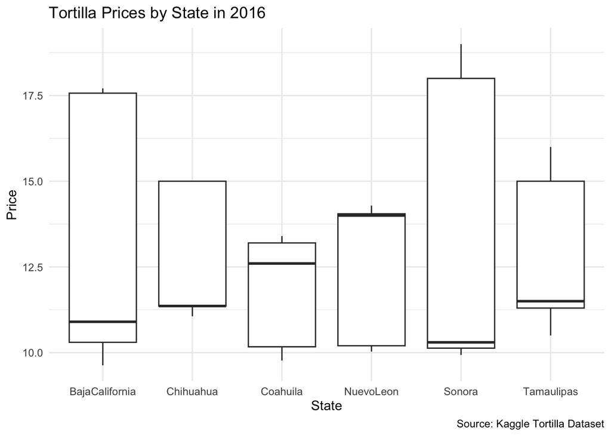

```r
#Boxplots for each state in 2016
ggplot(tortilla_prices_data %>%
         filter(year == 2016), aes(x = state,
                                   y = price)) +
  geom_boxplot() +
  labs(
    x = "State",
    y = "Price",
    title = "Tortilla Prices by State in 2016",
    caption = "Source: Kaggle Tortilla Dataset"
  ) +
  theme_minimal()
```

**Task F:** For the state of Nuevo León, make an overlapping plot of the price of tortillas each year from 2007 to 2024 based on store type

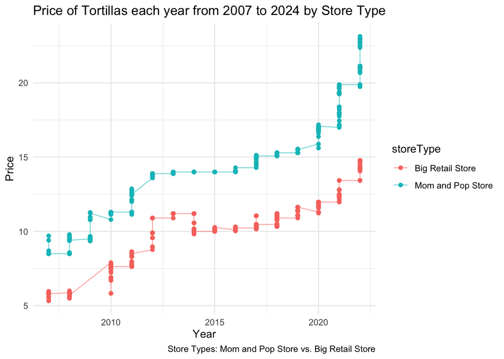

```r
#Filter data for Nuevo León
nuevo_leon_plot <- tortilla_prices_data %>%
  filter(state == "NuevoLeon")

# Create overlapping plot
ggplot(nuevo_leon_plot, aes(x = year,
                            y = price,
                            group = storeType,
                            color = storeType)) +
  geom_line(alpha = 0.5) +
  geom_point() +
  labs(
    x = "Year",
    y = "Price",
    title = "Price of Tortillas each year from 2007 to 2024 by Store Type",
    caption = "Store Types: Mom and Pop Store vs. Big Retail Store"
  ) +
  theme_minimal()
```

**Task G:** Image of Tortilla

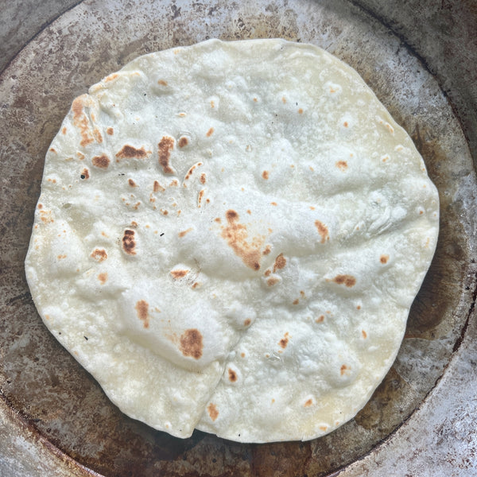

https://www.laboiteny.com/cdn/shop/articles/Flour_Tortilla_SQ_600x.jpg?v=1660671209

```r
#Prints image of a tortilla
include_graphics("/Users/giannadelorenzo/Downloads/STAT 184/Flour_Tortilla_SQ_600x.jpg")
```